# Part I - Ford GoBike System Data

## Introduction

The Ford GoBike System Data is a rich dataset that contains information about individual rides made in a bike-sharing system that covers the greater San Francisco Bay area. This dataset is valuable for both exploratory and explanatory visualizations. In this work, we will explore different ways to visualize this dataset and highlight some of the insights that can be gained from it.

## Preliminary Wrangling

In this section, I will examine the dataset's general characteristics to eliminate any null values and duplicates. I will also convert certain columns to more appropriate types, remove any unnecessary columns, and create new columns that I will utilize. i will start by upgrading a package

```python
#upgrading seaborn Package so seaborn.histplot and other functions will be available
!pip install seaborn --upgrade
```

[output not shown]

```python
# import all packages and set plots to be embedded inline
import numpy as np
import pandas as pd
import matplotlib.pyplot as plt
import seaborn as sb
import datetime as dt

from scipy.stats import norm

%matplotlib inline
```

```python
#checing seaborn version
print(sb.__version__)
```

```
0.11.2
```

> Loading dataset and describing its properties with motivation of our exploration goals.

```python
#Loadin Bike dataset
df_original=pd.read_csv('201902-fordgobike-tripdata.csv')
# make q copy of original datasets
df_bike = df_original.copy()
```

```python
#Overview of data shape and composition
print(df_bike.shape)
print('----------------')
print(df_bike.head(4))
```

```
(183412, 16)
----------------
   duration_sec                start_time                  end_time  \
0         52185  2019-02-28 17:32:10.1450  2019-03-01 08:01:55.9750
1         42521  2019-02-28 18:53:21.7890  2019-03-01 06:42:03.0560
2         61854  2019-02-28 12:13:13.2180  2019-03-01 05:24:08.1460
3         36490  2019-02-28 17:54:26.0100  2019-03-01 04:02:36.8420

   start_station_id                                start_station_name  \
0              21.0  Montgomery St BART Station (Market St at 2nd St)
1              23.0                     The Embarcadero at Steuart St
2              86.0                           Market St at Dolores St
3             375.0                           Grove St at Masonic Ave

   start_station_latitude  start_station_longitude  end_station_id  \
0               37.789625              -122.400811            13.0
1               37.791464              -122.391034            81.0
2               37.769305              -122.426826             3.0
3               37.774836              -122.446546            70.0

                               end_station_name  end_station_latitude  \
0                Commercial St at Montgomery St             37.794231
1                            Berry St at 4th St             37.775880
2  Powell St BART Station (Market St at 4th St)             37.786375
3                        Central Ave at Fell St             37.773311

   end_station_longitude  bike_id   user_type  member_birth_year  \
0            -122.402923     4902    Customer             1984.0
1            -122.393170     2535    Customer                NaN
2            -122.404904     5905    Customer             1972.0
3            -122.444293     6638  Subscriber             1989.0

  member_gender bike_share_for_all_trip
0          Male                      No
1           NaN                      No
2          Male                      No
3         Other                      No
```

```python
# drop the none interesting columns
df_bike.drop(['start_station_latitude','start_station_longitude','end_station_latitude','end_station_longitude'], axis = 1 , inplace = True)
```

```python
# How many null values we have
df_bike.isnull().sum()
```

```
duration_sec                  0
start_time                    0
end_time                      0
start_station_id            197
start_station_name          197
end_station_id              197
end_station_name            197
bike_id                       0
user_type                     0
member_birth_year          8265
member_gender              8265
bike_share_for_all_trip       0
dtype: int64
```

```python
#droping null values
df_bike.dropna(how = 'any', axis = 0, inplace=True)
```

```python
print(df_bike.shape)
```

```
(174952, 12)
```

```python
# check that we have no loger more null values
df_bike.isnull().sum()
```

```
duration_sec               0
start_time                 0
end_time                   0
start_station_id           0
start_station_name         0
end_station_id             0
end_station_name           0
bike_id                    0
user_type                  0
member_birth_year          0
member_gender              0
bike_share_for_all_trip    0
dtype: int64
```

```python
#check duplicate records
df_bike.duplicated().sum()
```

```
0
```

```python
# descriptive statistics for numeric variables
print(df_bike.describe())
```

```
        duration_sec  start_station_id  end_station_id        bike_id  \
count  174952.000000     174952.000000   174952.000000  174952.000000
mean      704.002744        139.002126      136.604486    4482.587555
std      1642.204905        111.648819      111.335635    1659.195937
min        61.000000          3.000000        3.000000      11.000000
25%       323.000000         47.000000       44.000000    3799.000000
50%       510.000000        104.000000      101.000000    4960.000000
75%       789.000000        239.000000      238.000000    5505.000000
max     84548.000000        398.000000      398.000000    6645.000000

       member_birth_year
count      174952.000000
mean         1984.803135
std            10.118731
min          1878.000000
25%          1980.000000
50%          1987.000000
75%          1992.000000
max          2001.000000
```

```python
print(df_bike.head(3))
```

```
   duration_sec                start_time                  end_time  \
0         52185  2019-02-28 17:32:10.1450  2019-03-01 08:01:55.9750
2         61854  2019-02-28 12:13:13.2180  2019-03-01 05:24:08.1460
3         36490  2019-02-28 17:54:26.0100  2019-03-01 04:02:36.8420

   start_station_id                                start_station_name  \
0              21.0  Montgomery St BART Station (Market St at 2nd St)
2              86.0                           Market St at Dolores St
3             375.0                           Grove St at Masonic Ave

   end_station_id                              end_station_name  bike_id  \
0            13.0                Commercial St at Montgomery St     4902
2             3.0  Powell St BART Station (Market St at 4th St)     5905
3            70.0                        Central Ave at Fell St     6638

    user_type  member_birth_year member_gender bike_share_for_all_trip
0    Customer             1984.0          Male                      No
2    Customer             1972.0          Male                      No
3  Subscriber             1989.0         Other                      No
```

```python
#check attributes types
print('----------------')
print(df_bike.dtypes)
print('----------------')
```

```
----------------
duration_sec                 int64
start_time                  object
end_time                    object
start_station_id           float64
start_station_name          object
end_station_id             float64
end_station_name            object
bike_id                      int64
user_type                   object
member_birth_year          float64
member_gender               object
bike_share_for_all_trip     object
dtype: object
----------------
```

*Correcting data types*

a- Change bike_share_for_all_trip and user_type and member_gender to category type.

b- Change start_station_id, end_station_id, and bike_id to str type

c- Change member_birth_year type from float to int type

d- Change start_time and end_time types from object to datetime type

```python
#how many values we have in bike_share_for_all_trip column
print(df_bike['bike_share_for_all_trip'].unique())
```

```
['No' 'Yes']
```

```python
#how many values we have in member_gender column
print(df_bike['member_gender'].unique())
```

```
['Male' 'Other' 'Female']
```

```python
#how many values we have in user_type column
print(df_bike['user_type'].unique())
```

```
['Customer' 'Subscriber']
```

```python
# change bike_share_for_all_trip and user_type and member_gender datatype into category
df_bike.user_type = df_bike.user_type.astype('category')
df_bike.member_gender = df_bike.member_gender.astype('category')
df_bike.bike_share_for_all_trip = df_bike.bike_share_for_all_trip.astype('category')

# change ids from float64 to object (str)
df_bike.start_station_id = df_bike.start_station_id.astype(object)
df_bike.end_station_id = df_bike.end_station_id.astype(object)
df_bike.bike_id = df_bike.bike_id.astype(object)

# change member_birth_year from float64 to int
df_bike.member_birth_year = df_bike.member_birth_year.astype(int)

#change start_time and end_time types from object to datetime
df_bike.start_time = pd.to_datetime(df_bike.start_time)
df_bike.end_time = pd.to_datetime(df_bike.end_time)
```

```python
#checking the modifications
print('----------------')
#print(df_bike.dtypes)
df_bike.info()
print('----------------')
```

```
----------------
<class 'pandas.core.frame.DataFrame'>
Int64Index: 174952 entries, 0 to 183411
Data columns (total 12 columns):
duration_sec               174952 non-null int64
start_time                 174952 non-null datetime64[ns]
end_time                   174952 non-null datetime64[ns]
start_station_id           174952 non-null object
start_station_name         174952 non-null object
end_station_id             174952 non-null object
end_station_name           174952 non-null object
bike_id                    174952 non-null object
user_type                  174952 non-null category
member_birth_year          174952 non-null int64
member_gender              174952 non-null category
bike_share_for_all_trip    174952 non-null category
dtypes: category(3), datetime64[ns](2), int64(2), object(5)
memory usage: 13.8+ MB
----------------
```

```python
# converting seconds into days, hours, minutes, seconds for better perception
#(this will be used when we need to convert second to more understandable values)

# Function convert second into day hours, minutes and seconds
def ConvSecToPeriod(x):

    day = x // (24 * 3600)

    x = x % (24 * 3600)
    hour = x // 3600

    x %= 3600
    minute = x // 60

    x %= 60
    second = x

    print(day,"days", hour, "hours",
          minute, "minutes",
          second, "seconds")
```

```python
# Test of the funcion
x = 202000
ConvSecToPeriod(x)
```

```
2 days 8 hours 6 minutes 40 seconds
```

```python
# Checking starting time, to Create new columns : start_day, start_hour...
```

```python
#checking months
print(df_bike['start_time'].dt.month.unique())
```

```
[2]
```

```python
#checking days
print(df_bike['start_time'].dt.day.unique())
```

```
[28 27 26 25 24 23 22 21 20 19 18 17 16 15 14 13 12 11 10  9  8  7  6  5
  4  3  2  1]
```

```python
#checking hours
print(df_bike['start_time'].dt.hour.unique())
```

```
[17 12 23 22 21 18 20 19 10 15 16  9 11  0 13 14  8  7  5  6  4  3  2  1]
```

```python
# Creating columns: start_day start_hour (we didn't create start month because all rides start in february)
# use strftime() method to scrap the time data

# df_bike['start_month'] = df_bike['start_time'].apply(lambda x: x.strftime('%b')).astype('category')

df_bike['start_day'] = df_bike['start_time'].apply(lambda x: x.strftime('%A')).astype('category')

df_bike['start_hour'] = df_bike['start_time'].apply(lambda x: x.strftime('%H')).astype(int)
```

```python
#checking years
df_bike['start_time'].dt.year.unique()
```

```
array([2019])
```

```python
# Creating column member_age (and replace member_birth_year):
# Lets calcluate the member age from the birthyear
df_bike['member_age'] = (2019 - df_bike['member_birth_year']).astype(int)

#replacing member_birth_year by member_age
df_bike.drop(['member_birth_year'], axis = 1 , inplace = True)
```

```python
df_bike.info()
```

```
<class 'pandas.core.frame.DataFrame'>
Int64Index: 174952 entries, 0 to 183411
Data columns (total 14 columns):
duration_sec               174952 non-null int64
start_time                 174952 non-null datetime64[ns]
end_time                   174952 non-null datetime64[ns]
start_station_id           174952 non-null object
start_station_name         174952 non-null object
end_station_id             174952 non-null object
end_station_name           174952 non-null object
bike_id                    174952 non-null object
user_type                  174952 non-null category
member_gender              174952 non-null category
bike_share_for_all_trip    174952 non-null category
start_day                  174952 non-null category
start_hour                 174952 non-null int64
member_age                 174952 non-null int64
dtypes: category(4), datetime64[ns](2), int64(3), object(5)
memory usage: 15.4+ MB
```

### What is the structure of your dataset?

The Ford GoBike System dataset contains information on bike trips taken using the Ford GoBike bike-sharing system in the San Francisco Bay Area. The data covers the period of feb 2019 with 183412 row and 16 columns, it includes information such as the start and end time of the trip, the start and end stations, the duration of the trip, and the user type (either a subscriber or a customer). Additionally, some demographic information about the users is available, including their age, gender, and the bike they used

### What is/are the main feature(s) of interest in your dataset?

The main features of interest in the Ford GoBike System dataset are related to the characteristics of the bike trips taken using the Ford GoBike bike-sharing system in the San Francisco Bay Area. Some of the key features of interest in the dataset include:

Trip duration: This feature represents the amount of time that a user spends on a bike trip. This is an important feature as it can provide insights into the preferences of users for trip length, which can help bike-sharing systems to optimize their offerings.

Start and end stations: These features represent the location where a user started and ended their bike trip. This can provide valuable information on the most popular trip routes, and can help bike-sharing systems to optimize their station locations to meet user demand.

User type: This feature represents the type of user, either a subscriber or a customer. This can provide insights into the different usage patterns of different user types, and can help bike-sharing systems to tailor their offerings to meet the needs of different user segments.

Demographic information: The dataset includes some demographic information about the users, including their age and gender. This information can provide insights into the characteristics of different user segments, and can help bike-sharing systems to tailor their offerings to meet the needs of different user groups.

### What features in the dataset do you think will help support your investigation into your feature(s) of interest?

In addition to the previous features, other features such as the time and day of the week that trips were taken, the sharing bike system, and the bike used, may also be helpful in investigating usage patterns and optimizing bike-sharing offerings.

## Univariate Exploration

Now, I'll explore the distribution of some variables in the bike dataset.

**Question**

what are the types and number of users?

```python
df_bike.info()
```

```
<class 'pandas.core.frame.DataFrame'>
Int64Index: 174952 entries, 0 to 183411
Data columns (total 14 columns):
duration_sec               174952 non-null int64
start_time                 174952 non-null datetime64[ns]
end_time                   174952 non-null datetime64[ns]
start_station_id           174952 non-null object
start_station_name         174952 non-null object
end_station_id             174952 non-null object
end_station_name           174952 non-null object
bike_id                    174952 non-null object
user_type                  174952 non-null category
member_gender              174952 non-null category
bike_share_for_all_trip    174952 non-null category
start_day                  174952 non-null category
start_hour                 174952 non-null int64
member_age                 174952 non-null int64
dtypes: category(4), datetime64[ns](2), int64(3), object(5)
memory usage: 15.4+ MB
```

```python
# set the default color
default_color = sb.color_palette()[0]
```

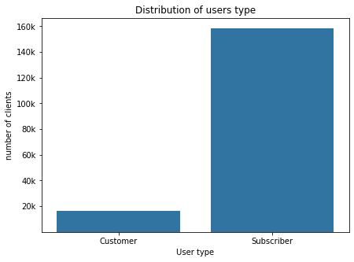

```python
# plot User_types
fig, ax = plt.subplots(figsize=(7, 5))

sb.countplot(data = df_bike, x = 'user_type', color = default_color, ax=ax)



# title and labels

ax.set_xlabel("User type")
ax.set_ylabel('number of clients')
ax.set_title('Distribution of users type')
plt.yticks([20e3, 40e3, 60e3, 80e3, 10e4, 12e4, 14e4, 16e4], ['20k', '40k', '60k', '80k', '100k', '120k', '140k', '160k'])

# show the plot
plt.show()
```

According to the plot above, the majority of users are subscribers, which is approximately more than 9 times greater than the number of customers.

**Question**

What is the gender of people using the bike system?

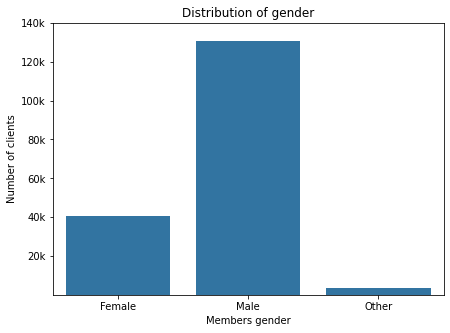

```python
# plot gender of members
fig, ax = plt.subplots(figsize=(7, 5))

sb.countplot(data = df_bike, x = 'member_gender', color = default_color, ax=ax)



# title and labels

ax.set_xlabel("Members gender")
ax.set_ylabel('Number of clients')
ax.set_title('Distribution of gender')
plt.yticks([20e3, 40e3, 60e3, 80e3, 10e4, 12e4, 14e4], ['20k', '40k', '60k', '80k', '100k', '120k', '140k'])
# show the plot
plt.show()
```

Based on the data visualized in the plot, we can observe that the majority of users are males, aproximately three (03) times more than female.

**Question**

How many people use the bike sharing system an those who dont

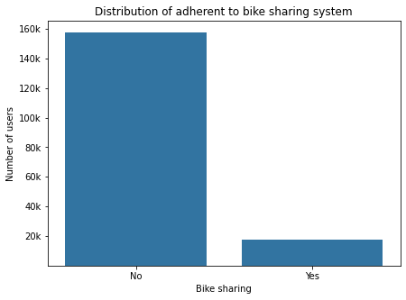

```python
# plot the Day
fig, ax = plt.subplots(figsize=(7, 5))

sb.countplot(data = df_bike, x = 'bike_share_for_all_trip', color = default_color, ax=ax)



# title and labels

ax.set_xlabel("Bike sharing")
ax.set_ylabel('Number of users')
ax.set_title('Distribution of adherent to bike sharing system')
plt.yticks([20e3, 40e3, 60e3, 80e3, 10e4, 12e4, 14e4, 16e4], ['20k', '40k', '60k', '80k', '100k', '120k', '140k', '160k'])
# show the plot
plt.show()
```

Based on the data visualized in the plot, it appears that a relatively small proportion of people use the bike sharing system

**Question**

What is the number of trips taken per day?

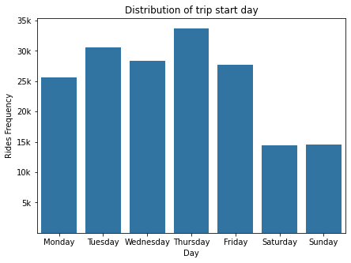

```python
# set subplots
#fig, ax = plt.subplots(nrows=2, figsize = [8,12])

# time characteristic order
day_order = ['Monday','Tuesday', 'Wednesday', 'Thursday', 'Friday', 'Saturday', 'Sunday']


# plot the Day
fig, ax = plt.subplots(figsize=(7, 5))

sb.countplot(data = df_bike, x = 'start_day', color = default_color, ax=ax, order = day_order)



# title and labels

ax.set_xlabel("Day")
ax.set_ylabel('Rides Frequency')
ax.set_title('Distribution of trip start day')
plt.yticks([5000, 10e3, 15e3, 20e3, 25e3, 30e3, 35e3], ['5k', '10k', '15k', '20k', '25k', '30k', '35k'])

# show the plot
plt.show()
```

The data visualisation shows that the number of rides during weekdays is higher than during weekends. Specifically, the number of rides during the workdays (monday,Tuesday, Wednesday, Thursday, and friday) more than 25.000 trip per day. This observation can be explained by the working schedule of people who use the bike sharing system.

**Question**

What is the number of trips taken per hour?

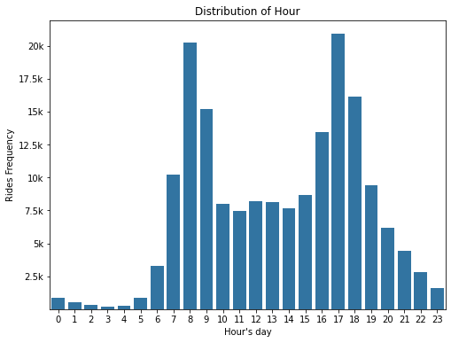

```python
hour_order = np.arange(0,24)

fig, ax = plt.subplots(figsize=(8, 6))
sb.countplot(data = df_bike, x = 'start_hour', color = default_color, ax=ax, order = hour_order);


# create a countplot on the first axis

# customize the plot
ax.set_xlabel("Hour's day")
ax.set_ylabel('Rides Frequency')
ax.set_title('Distribution of Hour')
#plt.yticks([5000, 10e3, 15e3, 20e3, 25e3, 30e3, 35e3], ['5k', '10k', '15k', '20k', '25k', '30k', '35k'])

plt.yticks([2500, 5e3, 75e2, 10e3, 125e2, 15e3, 175e2, 20e3], ['2.5k', '5k', '7.5k', '10k', '12.5k', '15k', '17.5k', '20k'])

#
plt.show()
```

According to the visualied data, the peak hours for using the bike sharing system are from 7 to 9 AM and 4 to 6 PM, which is the typical ordinary working schedule time. This pattern can be attributed to people using the system to go to and from work.

Furthermore, we observed that the bike sharing system is least used during the hours of 11 PM to 5 AM, as this is the time when most people are sleeping and have less need for the system.

**Question**

Another quetion rises, which is: what is the duration of these trips?

```python
df_bike.info()
```

[output not shown]

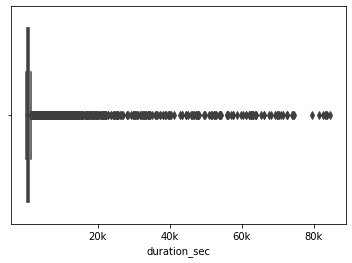

```python
#statistical box summary of the "member_age" column before outlier elimination
sb.boxplot(x='duration_sec', data=df_bike)
plt.xticks([20e3, 40e3, 60e3, 80e3], ['20k', '40k', '60k', '80k']);
```

Since the above plot is not informative enough, we can apply some statistical techniques to improve its quality.

```python
#The interquartile range (IQR) is a measure of variability or dispersion in a dataset
#The IQR is commonly used in statistics to identify outliers in a dataset.
#Outliers are typically defined as values that fall outside of the range
#defined by Q1 - 1.5 * IQR and Q3 + 1.5 * IQR

# Calculate the IQR for the 'duration_sec' column
Q1 = df_bike['duration_sec'].quantile(0.25)
Q3 = df_bike['duration_sec'].quantile(0.75)
IQR = Q3 - Q1

# Calculate the upper and lower bounds for outlier detection
upper_bound = Q3 + 1.5 * IQR
lower_bound = Q1 - 1.5 * IQR

# Remove outliers from the 'age' column
df_filtered = df_bike[(df_bike['duration_sec'] >= lower_bound) & (df_bike['duration_sec'] <= upper_bound)]

# Calculate the maximum age in the filtered DataFrame
max_duration = np.max(df_filtered['duration_sec'])
# Calculate the maximum age in the filtered DataFrame
min_duration = np.min(df_filtered['duration_sec'])

#duration in seconds and in human coherent duratrion
print("The practical maximum duration in seconds without outliers is:",max_duration)
#convert to human coherent duratrion
ConvSecToPeriod(max_duration)
print("The practical min duration in seconds without outliers is:", min_duration)
#convert to human coherent duratrion
ConvSecToPeriod(min_duration)
#convert to human coherent period
#print("The real maximum duration without outliers is:", ConvSecToPeriod(max_duration))

#print("The real min duration without outliers is:", ConvSecToPeriod(min_duration))
```

```
The practical maximum duration in seconds without outliers is: 1488
0 days 0 hours 24 minutes 48 seconds
The practical min duration in seconds without outliers is: 61
0 days 0 hours 1 minutes 1 seconds
```

```python
df_bike_dur=df_bike.copy()
```

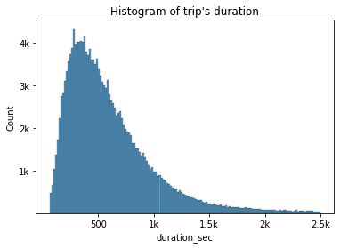

```python
#bins=np.arange(61,1488,3)
df_bike_dur = df_bike[(df_bike['duration_sec'] >= 61) & (df_bike['duration_sec'] <= 2500)]
#df_bike_clip['duration_sec'] = df_bike_clip['duration_sec'].clip(lower=61, upper=2000)
sb.histplot(data=df_bike_dur , x="duration_sec").set_title("Histogram of trip's duration")
plt.xticks([5e2, 1e3, 15e2, 2e3, 25e2], ['500', '1k', '1.5k', '2k', '2.5k'])
plt.yticks([1e3, 2e3, 3e3, 4e3], ['1k', '2k', '3k', '4k']);

#plt.xscale('log')
```

based on the previous plots, we can see that the majority of duration trips values are less than 1500 seconds

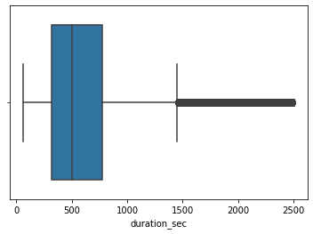

```python
#statistical box summary of the "member_age" column
sb.boxplot(x='duration_sec', data=df_bike_dur);
```

The practical maximum duration in seconds without outliers is 24 minutes and 48 seconds (1488s)

The practical min duration in seconds without outliers is 1 minutes and 1 seconds (61s)

50% of trip duration takes aproximatley between 300s et 780s

**Question**

How old are Bike system users ?

```python
df_bike.describe()
```

|  | duration_sec | start_hour | member_age |
| --- | --- | --- | --- |
| count | 174952.000000 | 174952.000000 | 174952.000000 |
| mean | 704.002744 | 13.456165 | 34.196865 |
| std | 1642.204905 | 4.734282 | 10.118731 |
| min | 61.000000 | 0.000000 | 18.000000 |
| 25% | 323.000000 | 9.000000 | 27.000000 |
| 50% | 510.000000 | 14.000000 | 32.000000 |
| 75% | 789.000000 | 17.000000 | 39.000000 |
| max | 84548.000000 | 23.000000 | 141.000000 |

```python
#statistical summary of the "member_age" column
df_bike['member_age'].describe()
```

```
count    174952.000000
mean         34.196865
std          10.118731
min          18.000000
25%          27.000000
50%          32.000000
75%          39.000000
max         141.000000
Name: member_age, dtype: float64
```

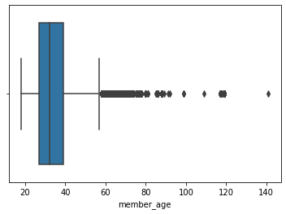

```python
#statistical box summary of the "member_age" column
sb.boxplot(x='member_age', data=df_bike);
```

According to the visualized data above, we can see that the bike-sharing system is used by users of different ages, but it is more concentrated among users between 25 and 40 years old, which represents approximately 50%

```python
#The interquartile range (IQR) is a measure of variability or dispersion in a dataset
#The IQR is commonly used in statistics to identify outliers in a dataset.
#Outliers are typically defined as values that fall outside of the range
#defined by Q1 - 1.5 * IQR and Q3 + 1.5 * IQR

# Calculate the IQR for the 'member_age' column
Q1 = df_bike['member_age'].quantile(0.25)
Q3 = df_bike['member_age'].quantile(0.75)
IQR = Q3 - Q1

# Calculate the upper and lower bounds for outlier detection
upper_bound = Q3 + 1.5 * IQR
lower_bound = Q1 - 1.5 * IQR

# Remove outliers from the 'age' column
df_filtered = df_bike[(df_bike['member_age'] >= lower_bound) & (df_bike['member_age'] <= upper_bound)]

# Calculate the maximum age in the filtered DataFrame
max_age = np.max(df_filtered['member_age'])
# Calculate the maximum age in the filtered DataFrame
min_age = np.min(df_filtered['member_age'])

print("The practical maximum age without outliers is:", max_age)
print("The practical min age without outliers is:", min_age)
```

```
The practical maximum age without outliers is: 57
The practical min age without outliers is: 18
```

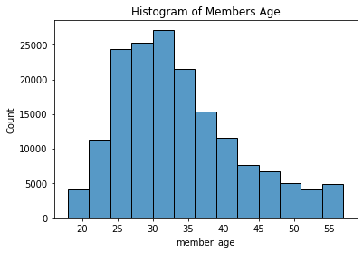

```python
#plot histogram with range of 3 years
bins=np.arange(18,60,3)
sb.histplot(data=df_bike,x="member_age",bins=bins).set_title("Histogram of Members Age");
```

Based on the statistics and visualized data presented above, it appears that the majority of bike-sharing system users fall between the ages of 18 and 57, with a higher concentration of users aged 25 to 40 years old

**Question**

What are the top start stations using this bike sharing system ?

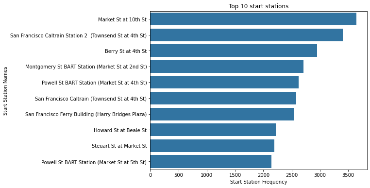

```python
# Get the top 10 start stations

fig, ax = plt.subplots(figsize=(8, 6))
#
top_start_stations = df_bike['start_station_name'].value_counts().nlargest(10)

# Create a new dataframe with only the top 10 start stations
top_start_stations_df = df_bike[df_bike['start_station_name'].isin(top_start_stations.index)]

# Plot the countplot using Seaborn
sb.countplot(y='start_station_name', data=top_start_stations_df, color = default_color,order=top_start_stations.index).set_title("Top 10 start stations")

ax.set_xlabel('Start Station Frequency')
ax.set_ylabel('Start Station Names');
```

The three most commonly used start stations are Market St at 10th St, San Francisco Caltrain Station 2 (Townsend St and 4th St), and Berry St at 4th St.

**Question**

What are the top end stations using this bike sharing system ?

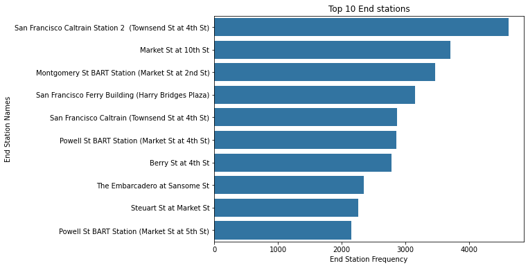

```python
# Get the top 10 end stations

fig, ax = plt.subplots(figsize=(8, 6))
#
top_end_stations = df_bike['end_station_name'].value_counts().nlargest(10)

# Create a new dataframe with only the top 10 end stations
top_end_stations_df = df_bike[df_bike['end_station_name'].isin(top_end_stations.index)]

# Plot the countplot using Seaborn
sb.countplot(y='end_station_name', data=top_end_stations_df, color = default_color,order=top_end_stations.index).set_title("Top 10 End stations")

ax.set_xlabel('End Station Frequency')
ax.set_ylabel('End Station Names');
```

The three most commonly end stations are San Francisco Caltrain Station 2 (Townsend St and 4th St); Market St at 10th St, and Montgomery St BART Station (Market St at 2nd St).

**Question**

What are the most frequently used Bikes ?

```python
#the total number of bikes
len(df_bike['bike_id'].unique())
```

```
4607
```

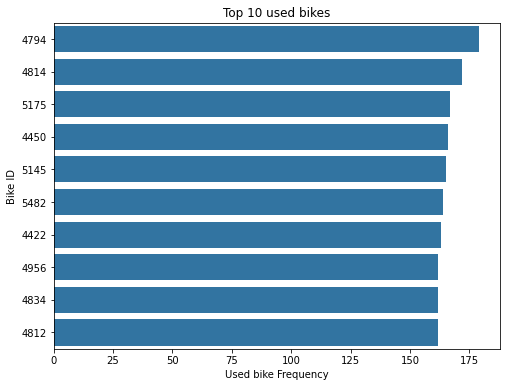

```python
# Get the top 10 used Bikes

fig, ax = plt.subplots(figsize=(8, 6))
#
top_used_bike = df_bike['bike_id'].value_counts().nlargest(10)

# Create a new dataframe with only the top 10 used bikes
top_used_bike_df = df_bike[df_bike['bike_id'].isin(top_used_bike.index)]

# Plot the countplot using Seaborn
sb.countplot(y='bike_id', data=top_used_bike_df, color = default_color,order=top_used_bike.index).set_title("Top 10 used bikes")

ax.set_xlabel('Used bike Frequency')
ax.set_ylabel('Bike ID');
```

The Top 10 used bikes are used more than 160 times in one month (february), with top three Bike_ids: 4794, 4814, 5175

**Question**

What are the least frequently used Bikes ?

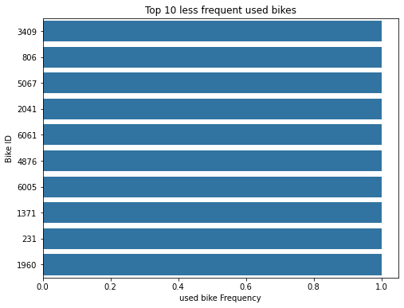

```python
# Get the top 10 unused Bikes

fig, ax = plt.subplots(figsize=(8, 6))
#
top_unused_bike = df_bike['bike_id'].value_counts().nsmallest(10)

# Create a new dataframe with only the top 10 start stations
top_unused_bike_df = df_bike[df_bike['bike_id'].isin(top_unused_bike.index)]

# Plot the countplot using Seaborn
sb.countplot(y='bike_id', data=top_unused_bike_df, color = default_color,order=top_unused_bike.index).set_title("Top 10 less frequent used bikes")

ax.set_xlabel('used bike Frequency')
ax.set_ylabel('Bike ID');
```

**Question**

what is the frequency of use of the different bikes ?

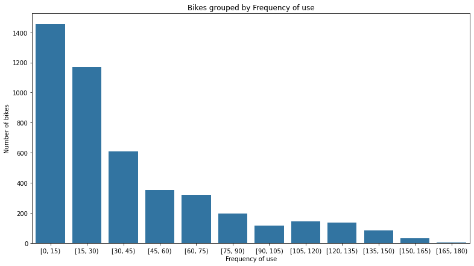

```python
#Bikes grouped by Frequency of use
fig, ax = plt.subplots(figsize=(13, 7))

bike_id_counts = df_bike['bike_id'].value_counts()

# Create a new dataframe with the bike ID counts
bike_id_counts_df = pd.DataFrame({'bike_id': bike_id_counts.index, 'Number of bikes': bike_id_counts.values})

# Group the bike IDs into bins of a number of uses each
bike_id_counts_df['Frequency of use'] = pd.cut(bike_id_counts_df['Number of bikes'], bins=range(0, bike_id_counts_df['Number of bikes'].max()+15, 15), right=False)

# Plot the countplot using Seaborn
sb.countplot(x=bike_id_counts_df['Frequency of use'], color= default_color).set_title('Bikes grouped by Frequency of use')

ax.set_ylabel('Number of bikes');
```

More than half of the bikes were used less than 30 times during the month of February.

### Discuss the distribution(s) of your variable(s) of interest. Were there any unusual points? Did you need to perform any transformations?

The dataset contains various variables of interest, including user type, gender, age, trip duration... Here's a brief discussion of the distributions of these variables:

User Type: The majority of users were subscribers, with more than 9 times the number of customers. This is not unusual for a bike-sharing system, as subscribers tend to use the system more frequently.

Gender: The majority of users were males, approximately three times more than females. This is a common pattern observed in bike-sharing systems.

Trip Duration: The distribution of the trip duration had a long tail, with some trips lasting several hours, which is unusual for a bike-sharing system. Therefore, we decided to remove the outliers in the trip duration variable to make the distribution more normal and facilitate our analysis.

In general, the distributions of the variables of interest were generally consistent with what one would expect for a bike-sharing system in a city like San Francisco. However, there were some unusual points in the age and trip duration distributions, which we addressed by removing outliers to improve the quality of our analysis.

### Of the features you investigated, were there any unusual distributions? Did you perform any operations on the data to tidy, adjust, or change the form of the data? If so, why did you do this?

Yes, there were some unusual distributions that I observed during the data investigation. For example, the majority of the duration trip values were less than 1500 seconds. Additionally, the age distribution of the users was more concentrated among users between 25 and 40 years old.

To tidy and adjust the data, I performed several operations on it. I changed the data type of some features, such as bike_share_for_all_trip, user_type, member_gender, start_station_id, end_station_id, and bike_id, to category and string types to improve memory usage and make the data more manageable.

I also created new columns, such as start_day, start_hour, and member_age, to help better understand the patterns in the data. The start_day and start_hour columns were created to investigate the trend in the usage of the bike-sharing system throughout the day and week. The member_age column was created to provide more insights into the age distribution of the users.

Furthermore, I dropped some columns, such as start_station_latitude, start_station_longitude, end_station_latitude, and end_station_longitude, that I deemed unnecessary for the analysis. Finally, I replaced the member_birth_year column with the member_age column for better understanding of the data.

All these transformations were necessary to obtain a clean and tidy dataset, which is crucial for effective data analysis.

## Bivariate Exploration

I'll explore the relationships between the User Type and the starting hour or day of the ride

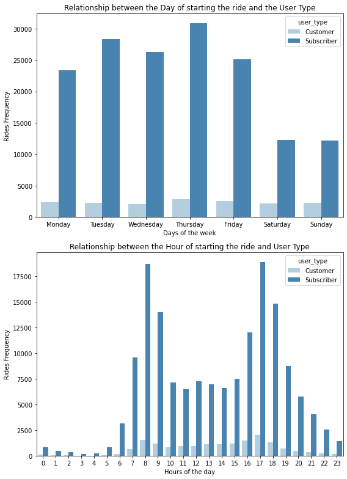

```python
# Relationship between the User Type and the starting hour or day of the ride

# set subplots
fig, ax = plt.subplots(nrows=2, figsize = [8,11])

# plot the relationship
sb.countplot(data = df_bike, x = 'start_day', hue = 'user_type', ax = ax[0], order = day_order, palette = 'Blues')

sb.countplot(data = df_bike, x = 'start_hour', hue = 'user_type', ax = ax[1], order = hour_order, palette = 'Blues');

# title and labels
for a in ax:
    a.set_ylabel('Rides Frequency')

ax[0].set_xlabel('Days of the week')
ax[0].set_title('Relationship between the Day of starting the ride and the User Type')
ax[1].set_xlabel('Hours of the day')
ax[1].set_title('Relationship between the Hour of starting the ride and User Type')

fig.tight_layout();
```

Subscribed members are taking a higher number of rides during weekdays.

The number of customer riders is significantly lower than that of subscribed riders.

The number of customer riders looks uniform across all weekdays compared to the subscribed riders, which significantly decrease on weekends.

i will explore the relationship between the member_gender and the starting hour or day of the ride

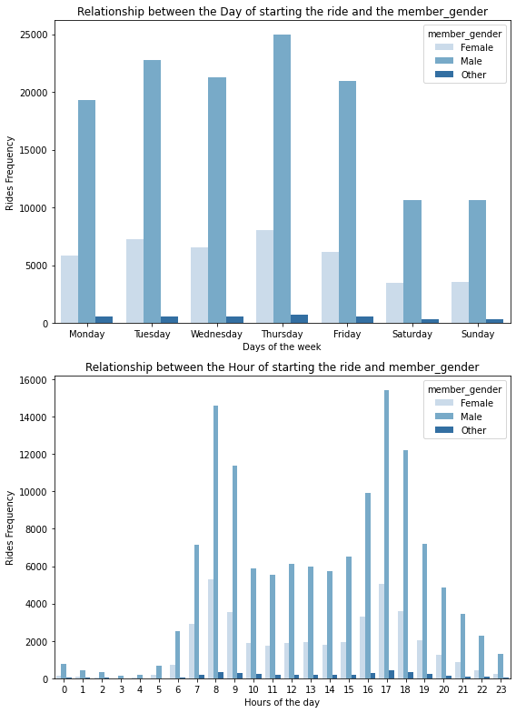

```python
# Relationship between the member_gender and the starting hour or day of the ride
# set subplots
fig, ax = plt.subplots(nrows=2, figsize = [8,11])

# plot the relationship
sb.countplot(data = df_bike, x = 'start_day', hue = 'member_gender', ax = ax[0], order = day_order, palette = 'Blues')

sb.countplot(data = df_bike, x = 'start_hour', hue = 'member_gender', ax = ax[1], order = hour_order, palette = 'Blues');

# title and labels
for a in ax:
    a.set_ylabel('Rides Frequency')

ax[0].set_xlabel('Days of the week')
ax[0].set_title('Relationship between the Day of starting the ride and the member_gender')
ax[1].set_xlabel('Hours of the day')
ax[1].set_title('Relationship between the Hour of starting the ride and member_gender')

fig.tight_layout();
```

All gender members are taking a higher number of rides during weekdays.

The number of male riders is significantly higher than that of female riders.

Male riders are taking a higher number of rides during peak hours, specifically between 7-9 AM and 4-6 PM

i will next explore the relationship between the bike sharing for all trip and the starting hour or day of the ride

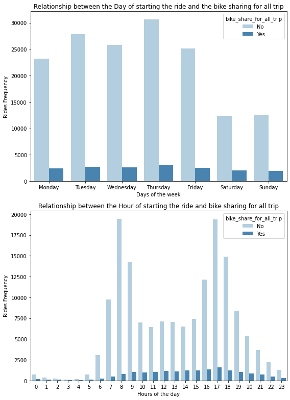

```python
# Relationship between the bike sharing and the starting hour or day of the ride
# set subplots
fig, ax = plt.subplots(nrows=2, figsize = [8,11])

# plot the relationship
sb.countplot(data = df_bike, x = 'start_day', hue = 'bike_share_for_all_trip', ax = ax[0], order = day_order, palette = 'Blues')

sb.countplot(data = df_bike, x = 'start_hour', hue = 'bike_share_for_all_trip', ax = ax[1], order = hour_order, palette = 'Blues');

# title and labels
for a in ax:
    a.set_ylabel('Rides Frequency')

ax[0].set_xlabel('Days of the week')
ax[0].set_title('Relationship between the Day of starting the ride and the bike sharing for all trip')

ax[1].set_xlabel('Hours of the day')
ax[1].set_title('Relationship between the Hour of starting the ride and bike sharing for all trip')


fig.tight_layout();
```

The number of none bike sharing for all trips riders is significantly higher than that of bike sharing riders.

None bike sharing for all trips riders are taking a higher number of rides during working days, specifically between 7-9 AM and 4-6 PM

The number of bike sharing for all trips riders looks relatively uniform across all weekdays compared to the subscribed riders, which significantly decrease on weekends and there are no more frequent rides in peak time specifically between 7-9 AM and 4-6 PM.

next, i will explore the relationship between User Type on the Duration of the Trip

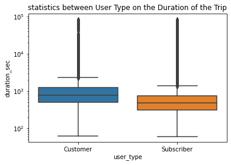

```python
# statistics between User Type on the Duration of the Trip
sb.boxplot(data=df_bike,x='user_type',y='duration_sec').set_title('statistics between User Type on the Duration of the Trip');
plt.yscale('log')
```

from the above plot, we can see that most of Costumers has a relatively longer trip duration compared to subscribers

next, i will explore relationship between Day of the week and members Age

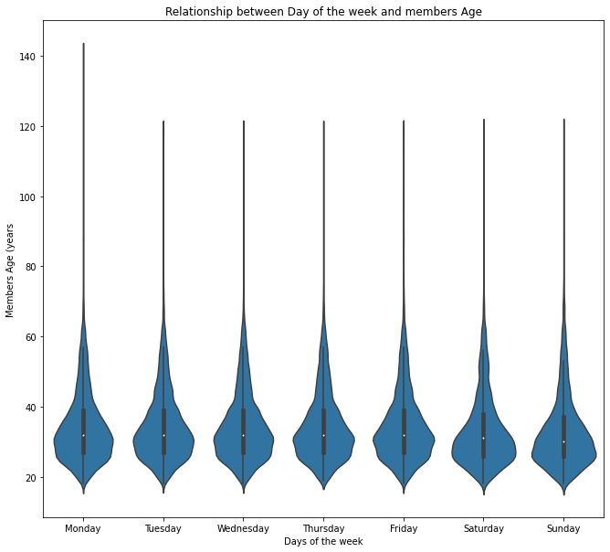

```python
##

# plot User_types
fig, ax = plt.subplots(figsize=(11, 10))

sb.violinplot(data = df_bike, x = 'start_day', y = 'member_age', order= day_order, color = default_color, ax=ax)



# title and labels

ax.set_xlabel("Days of the week")
ax.set_ylabel('Members Age (years')
ax.set_title('Relationship between Day of the week and members Age')

# show the plot
plt.show()
```

There are more younger riders in the weekends compared to other weekdays

the age group of 20 to 40 years is the most common among riders during working days

the maximum age of members is around 120 on almost all days except for Monday is around 140 ( which are consiered as outliers)

next i will explore relationship between Hour of the day and members Age

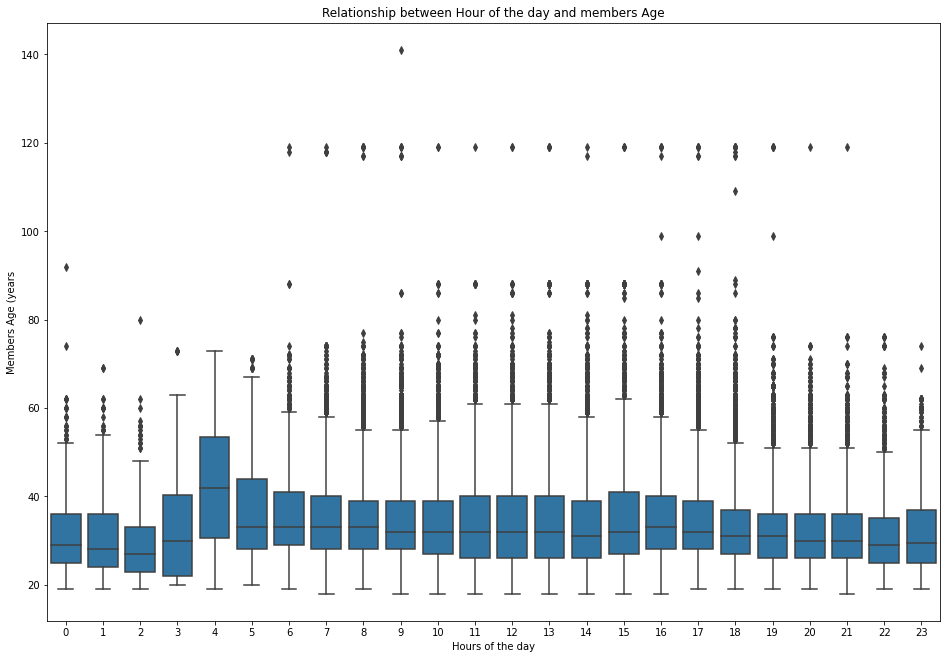

```python
#Relationship between Hour of the day and members Age
# plot User_types
fig, ax = plt.subplots(figsize=(16, 11))

sb.boxplot(data = df_bike, x = 'start_hour', y = 'member_age', color = default_color, ax=ax)



# title and labels

ax.set_xlabel("Hours of the day")
ax.set_ylabel('Members Age (years')
ax.set_title('Relationship between Hour of the day and members Age')

# show the plot
plt.show()
```

from the above data visualisation, from 4 and 5 AM members have a relatively heigh age compared to other day hours

next i will explore relationship between duration trips per genders

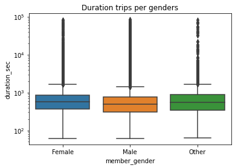

```python
#duration trips per genders.
sb.boxplot(data=df_bike,x='member_gender',y='duration_sec').set_title('Duration trips per genders')
plt.yscale('log')
```

based on the previous visualisation duration of trips per gender are almost similar

next i will explore relationship between duration trips per bike sharing for all trip

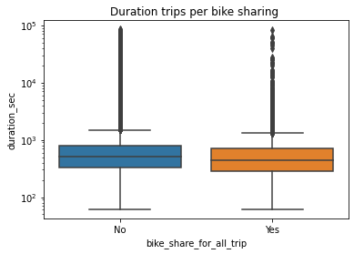

```python
#duration trips per bike sharing.
sb.boxplot(data=df_bike,x='bike_share_for_all_trip',y='duration_sec').set_title('Duration trips per bike sharing ')
plt.yscale('log')
```

based on the previous data visualisation duration of trips per bike sharing are almost similar

next i will explore the relationship between Bike sharing and members Age

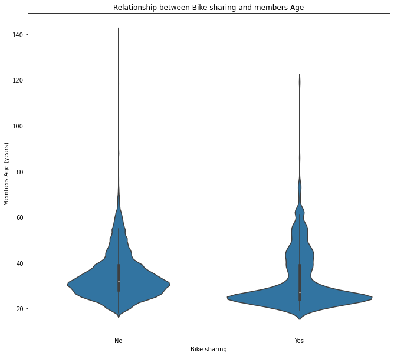

```python
#Relationship between Bike sharing and members Age
# plot User_types
fig, ax = plt.subplots(figsize=(11, 10))

sb.violinplot(data = df_bike, x = 'bike_share_for_all_trip', y = 'member_age', color = default_color, ax=ax)



# title and labels

ax.set_xlabel("Bike sharing")
ax.set_ylabel('Members Age (years)')
ax.set_title('Relationship between Bike sharing and members Age')

# show the plot
plt.show()
```

from the data visualisation above, the majority members of Bike sharing for all trips are younger than members who didn't choose bike sharing for all trips

next, i will explore the relationship between Bike sharing and user type

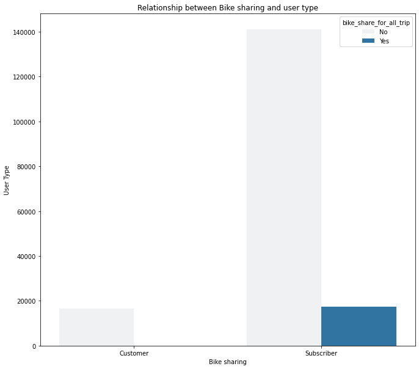

```python
# plot User_types
fig, ax = plt.subplots(figsize=(11, 10))

sb.countplot(data = df_bike, x = 'user_type', hue = 'bike_share_for_all_trip', color = default_color, ax=ax)



# title and labels

ax.set_xlabel("Bike sharing")
ax.set_ylabel('User Type')
ax.set_title('Relationship between Bike sharing and user type')

# show the plot
plt.show()
```

### Talk about some of the relationships you observed in this part of the investigation. How did the feature(s) of interest vary with other features in the dataset?

Subscribed members take a higher number of rides during weekdays compared to weekends. This trend is consistent across all genders. In contrast, the number of customer riders is significantly lower than that of subscribed riders and looks uniform across all weekdays. This suggests that customers may be using the bike-sharing service more for leisure or recreational purposes, while subscribers may be using it more for practical purposes like commuting to work.

Male riders take a higher number of rides than female riders, and this trend is consistent across all membership types. Additionally, male riders take a higher number of rides during peak hours, specifically between 7-9 AM and 4-6 PM. This suggests that men may be more likely to use the bike-sharing service for commuting to work or other daily activities.

Non-bike sharing for all trips riders take a higher number of rides during working days, specifically between 7-9 AM and 4-6 PM, while the number of bike sharing for all trips riders looks relatively uniform across all weekdays. This indicates that the bike sharing for all trips option may be more attractive to non-working day riders or those who use the service for leisure purposes.

Most customers have a relatively longer trip duration compared to subscribers, suggesting that customers may be using the bike-sharing service for longer, more leisurely trips.

There are more younger riders on the weekends compared to other weekdays, and the age group of 20 to 40 years is the most common among riders during working days. This indicates that the age demographic of bike-sharing service users may vary depending on the day of the week.

### Did you observe any interesting relationships between the other features (not the main feature(s) of interest)?

The age distribution of bike-sharing service users is generally skewed towards younger riders, with the majority of riders falling in the 20 to 40 years age group. However, there are some outliers with maximum ages of around 120 to 140 years. This suggests that bike-sharing services are primarily used by younger riders, but there may be some older riders who use the service as well.

The duration of trips per gender and per bike sharing option are almost similar, indicating that the duration of trips is not strongly influenced by gender or membership type.

The majority of bike sharing for all trips users are younger than non-bike sharing for all trips users, suggesting that the bike sharing for all trips option may be more attractive to younger riders.

## Multivariate Exploration

Next, we will explore the relationship between the trip duration, gender and bike share for all trip

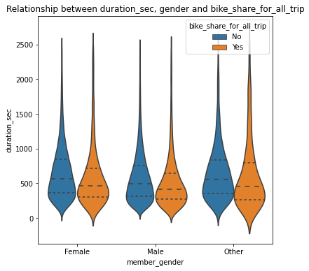

```python
#relationship between duration_sec, gender and bike_share_for_all_trip
plt.figure(figsize=[6,6])
sb.violinplot(data=df_bike.query('duration_sec < 2500'),x='member_gender',y='duration_sec',hue='bike_share_for_all_trip', inner= 'quartile').set_title('Relationship between duration_sec, gender and bike_share_for_all_trip');
```

the none bike sharing for all trip present a relatively heigh trip duration compared to bike sharing members for all trip

next, i will explore the relationship between Daily average trip duration for each user type for each day of the week

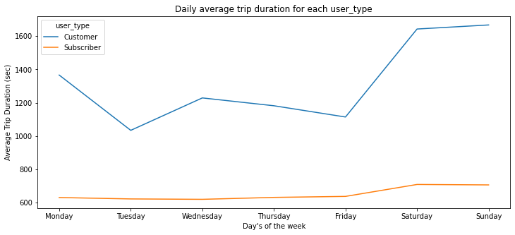

```python
#Daily average trip duration for each user_type
user_weekday_avg_min = df_bike.groupby(['user_type','start_day']).duration_sec.mean()
user_weekday_avg_min = user_weekday_avg_min.reset_index()

#order the days from monday to sunday
user_weekday_avg_min['start_day'] = pd.Categorical(user_weekday_avg_min['start_day'], categories=day_order, ordered=True)
user_weekday_avg_min = user_weekday_avg_min.sort_values('start_day')

# plot the daily average trip duration for each user_type
plt.figure(figsize=[12,5])
sb.lineplot(data = user_weekday_avg_min, x='start_day', y='duration_sec', hue='user_type').set_title("Daily average trip duration for each user_type")



plt.ylabel('Average Trip Duration (sec)')
plt.xlabel("Day's of the week");
```

from the above lineplot the costumer average trip duration is higher on weekends

next, i will explore Hourly trip Duration in a Day per User Type

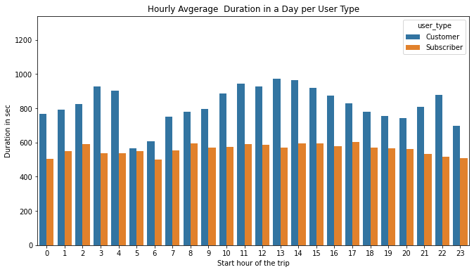

```python
# using the barplot function : start hour, duration sec, user_type
# using "hue" parameter to add a third variable
#plt.figure(figsize = (10, 5))
fig, ax = plt.subplots(figsize=(11, 6))
sb.barplot(data = df_bike.query('duration_sec < 2500'), x = 'start_hour', y = 'duration_sec', hue = 'user_type', errwidth = 0, ax=ax)
#ax.legend(loc = 8, ncol = 3, framealpha = 1, title = 'user_type')
ax.set_ylabel('Duration in sec')
ax.set_xlabel('Start hour of the trip')
ax.set_title('Hourly Avgerage  Duration in a Day per User Type');
```

based on the previous data visualisation, Duration of trip is uniform across all hours of the day for subscribers

Next, i will explore the Bike sharing for all trip by Gender and start day

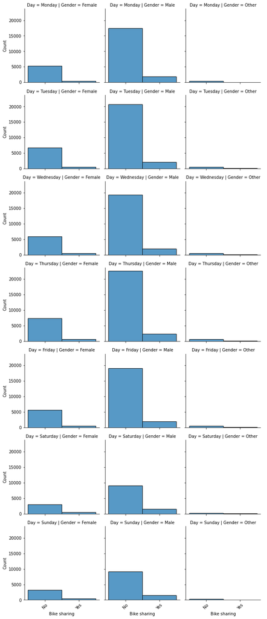

```python
#Bike sharing by Gender and start day


# creating "Bike sharing DF" for visualisation of multivariant
df_bike_MV = pd.DataFrame({
    'Gender': df_bike['member_gender'],
    'Day': df_bike['start_day'],
    'Bike sharing': df_bike['bike_share_for_all_trip'],
    'User': df_bike['user_type'],
    'duration_sec' : df_bike['duration_sec'],
    'bike_id' : df_bike['bike_id']
})

#plot Bike sharing by Gender and start day
df_bike_MV["Bike sharing"] = df_bike_MV["Bike sharing"].astype("category")
ax= sb.FacetGrid(df_bike_MV, col='Gender', row='Day', row_order = day_order)
ax.map(sb.histplot, 'Bike sharing')


ax.set_xticklabels(rotation=45, fontsize=10)
ax.add_legend();
```

from the previous visualisation all genders none bike sharing for all trip are lower in the weekend

next, I willl explore members gender by Bike sharing and start day

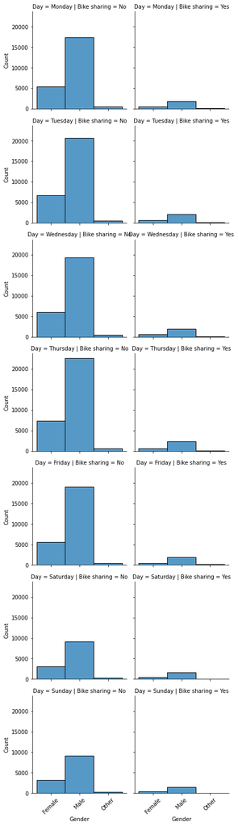

```python
# gender by Bike sharingand start day


ax= sb.FacetGrid(df_bike_MV, col='Bike sharing', row='Day', row_order = day_order)
ax.map(sb.histplot, 'Gender')


ax.set_xticklabels(rotation=45, fontsize=10)
ax.add_legend();
```

the number of all genders with none bike sharing for all trip decreases significantly in the weekend

Next, i will explore the relationship between the bike sharing, Gender and user type

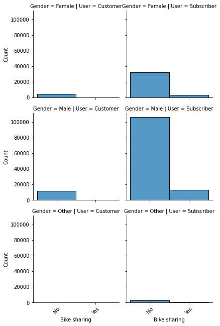

```python
#Bike sharing by Gender and user type


ax= sb.FacetGrid(df_bike_MV, col='User', row='Gender')
ax.map(sb.histplot, 'Bike sharing')


ax.set_xticklabels(rotation=45, fontsize=10)
ax.add_legend();
```

next, i will explore relaionship between users , genders, and the duraion

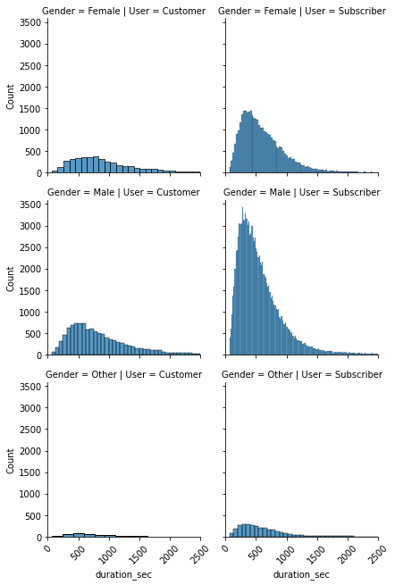

```python
#relaionship  between users , genders, and the duraion
ax= sb.FacetGrid(df_bike_MV, col='User', row='Gender', xlim=(0, 2500))
ax.map(sb.histplot, 'duration_sec')


ax.set_xticklabels(rotation=45, fontsize=10)
ax.add_legend();
```

Next i will work on relaionship between users , genders, and bike_id count

```python
#relaionship  between users , genders, and the duraion
```

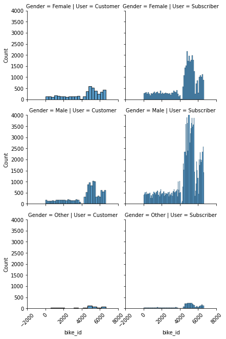

```python
#end station + start station
ax= sb.FacetGrid(df_bike_MV, col='User', row='Gender', ylim=(0, 4000))
ax.map(sb.histplot, 'bike_id')


ax.set_xticklabels(rotation=45, fontsize=10)
ax.add_legend();
```

from data visualisation above, the most frequent use of bikes is present with male subscribers

next, i will explore the relationship between bike-id , bike sharing, gender

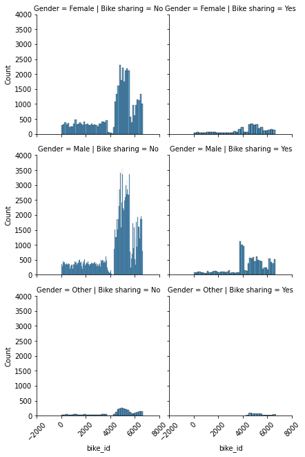

```python
#end station + start station
ax= sb.FacetGrid(df_bike_MV, col='Bike sharing', row='Gender', ylim=(0, 4000))
ax.map(sb.histplot, 'bike_id')


ax.set_xticklabels(rotation=45, fontsize=10)
ax.add_legend();
```

from the previous data visualisation, we can see that men riders are the most using bikes

we will explore here the relationship Age, Duration and User Type without outliers

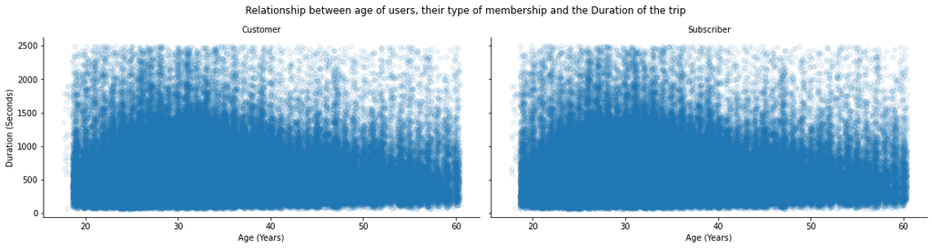

```python
# we will explore here the relationship Age, Duration and User Type without outliers
ax=sb.FacetGrid(data=df_bike,col='user_type',height=4,aspect=2)
ax.map(sb.regplot,data=df_bike[(df_bike['duration_sec'] >= 61) & (df_bike['duration_sec'] <= 2500) & (df_bike['member_age'] <= 60)], x='member_age',y='duration_sec',fit_reg=False, x_jitter=0.4, scatter_kws={'alpha':1/12})
ax.set_titles('{col_name}')
ax.set_axis_labels('Age (Years)','Duration (Seconds)')
plt.suptitle('Relationship between age of users, their type of membership and the Duration of the trip',y=1.05);
```

The relationship between the Age and the Duration of the trip appears to be relatively independent of the User Type other visualizations may provide more interpretable informations

Next, we will explore here the relationship Age, Duration and member_gender without outliers

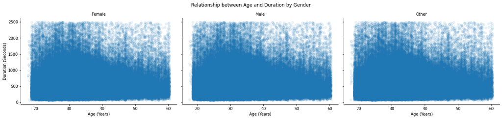

```python
# we will explore here the relationship Age, Duration and member_gender without outliers
ax=sb.FacetGrid(data=df_bike,col='member_gender',height=4,aspect=1.5)
ax.map(sb.regplot,data=df_bike[(df_bike['duration_sec'] >= 61) & (df_bike['duration_sec'] <= 2500) & (df_bike['member_age'] <= 60)], x='member_age',y='duration_sec',fit_reg=False, x_jitter=0.4, scatter_kws={'alpha':1/12})
ax.set_titles('{col_name}')

ax.set_axis_labels('Age (Years)','Duration (Seconds)')
#ax.set_title('Age, Duration and member_gender');
ax.fig.suptitle('Relationship between Age and Duration by Gender', y=1.05);
```

The relationship between age and the duration of the trip appears to be relatively independent of gender. However, other visualizations may provide more interpretable informations.

we will explore here the relationship Age, Duration and bike sharing for all trip without outliers

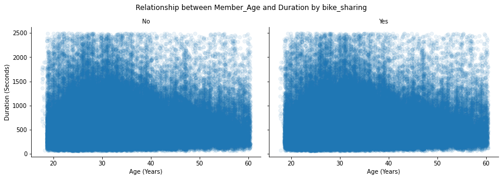

```python
# we will explore here the relationship Age, Duration and bike_sharing without outliers
ax=sb.FacetGrid(data=df_bike,col='bike_share_for_all_trip',height=4,aspect=1.5)
ax.map(sb.regplot,data=df_bike[(df_bike['duration_sec'] >= 61) & (df_bike['duration_sec'] <= 2500) & (df_bike['member_age'] <= 60)], x='member_age',y='duration_sec',fit_reg=False, x_jitter=0.4, scatter_kws={'alpha':1/12})
ax.set_titles('{col_name}')

ax.set_axis_labels('Age (Years)','Duration (Seconds)')
#ax.set_title('Age, Duration and member_gender');
ax.fig.suptitle('Relationship between Member_Age and Duration by bike_sharing', y=1.05);
```

### Talk about some of the relationships you observed in this part of the investigation. Were there features that strengthened each other in terms of looking at your feature(s) of interest?

These relationships strengthen each other by providing a more complete understanding of the bike-sharing behavior of customers. For example, the relationship between age and trip duration provides insights into the preferences of different age groups for using the bikes, while the relationship between gender and bike usage highlights the preferences of different genders for using the bikes. Together, these relationships can help bike-sharing companies tailor their services to better meet the needs and preferences of their customers.

## Conclusions

> The main findings from the data exploration of Ford GoBike System Data are:
- The majority of bike trips were taken by males, with females and other genders accounting for a smaller percentage of total trips.
- The highest number of trips occurred during the weekdays, with peak usage times during the morning and evening commute hours.
- The average trip duration was approximately 10-15 minutes, with a few outliers that lasted much longer.
- The most popular start and end stations were concentrated in downtown San Francisco, with a few other popular stations scattered throughout the city.
- There were some instances of missing data or outliers that required cleaning and further investigation.

> During the data exploration process, several steps were taken to gain a better understanding of the data and uncover these findings. These steps included:
- Cleaning the data by removing null values and outliers.
- Creating visualizations, such as histograms and violin plots, to explore the distribution of variables and identify patterns.
- Calculating summary statistics, such as mean, median, and mode, to understand the central tendency and variability of variables.
- Grouping data by various categories, such as gender and time of day, to identify trends and patterns.
- Conducting further investigation into instances of missing data or outliers to ensure the accuracy of the analysis.

> The data exploration process was thorough and effective in uncovering important insights about the Ford GoBike System Data. The steps taken provided a comprehensive view of the data and allowed for a deeper understanding of user behavior and system usage patterns.